# Sesssion 5 Air Quality - Report Exercise

Tino Schneidewind

2025-05-24

## Telling a story from data

The objective of this report exercise is to practice visualizing data and using statistical metrics to tell a story from data. For this purpose I investigated the [*airquality*](https://www.rdocumentation.org/packages/datasets/versions/3.6.2/topics/airquality) data set with ozone as the target variable, which is publicly available and consists of daily measurements of environmental variables from May first to September 30th 1973 from New York (Table 1).

```r
# load libraries
library(lubridate);library(cowplot);library(kableExtra);library(slider);library(gridExtra);library(tidyverse)

# read data
airquality <- read_csv("../data/airquality.csv") |>

  mutate(
  # add date
  date = as.Date(paste0(as.character(Day),"-", as.character(Month), "-", "1973" ), , format="%d-%m-%Y"),

  # add day of week (dow)
  dow  = weekdays(date),

  # convert Temperature to degree Celsius
  Temp = (Temp - 32) * (5/9)
  )
```

Table 1: Variables of the airquality dataset.

| Variable | Unit | Site | Method |
| --- | --- | --- | --- |
| Ozone | ppb | Roosevelt Island | average from 13:00 to 15:00 |
| Solar radiation | langleys | Central Park | average from 8:00 to 12:00 at 4000-7700 Angstroms |
| Wind speed | mph | LaGuardia Airport | average from 7:00 and 10:00 |
| Temperature | °C | LaGuardia Airport | maximum daily |

### 1. Introduction

Ground level ozone is a threat to human health and leads to higher mortality and hospitalization rates $^1$. Ozone can form when pollutants from traffic or industry, like nitrous oxide, react with solar radiation $^{2,3}$. Therefore, ozone is highly abundant in populated and polluted urban areas like New York. The degree of the exposure to ozone and their health consequences depend on the ozone concentration, its timely distribution, and the variation of ozone. In order to decrease the potential health effects of dangerous ozone exposure, ozone must be monitored or sufficiently predicted from other more common meteorological variables. In this report exercise, I will investigate the seasonal and weekly patterns of ozone concentrations and determine possible single predictors of the ozone concentration like wind speed, solar shortwave radiation, and temperature. I hypothesize that ozone concentrations are higher in the summer due to increased solar radiation and from Monday to Friday due to increased traffic and industry activity. Furthermore, ozone should be best predicted by solar radiation, as it is integral to its formation.

### 2. Methods

When investigating the health effects of ozone, a health impacting concentration threshold must be defined. The threshold for dangerous ozone exposure is according to WHO standards 100 $\mu g/m^3$ over 8 hours, which corresponds to 51 ppb $^4$. The data was not investigated for outliers in its distribution, due to the extremes being of special interest in an exposure study.

```r
airquality <-  airquality |>

  # WHO threshold of 51 ppb
  mutate(
    thresh = if_else(Ozone > 51, "Above", "Below")
         )
```

In order to investigate the weekly and monthly cycle of ozone, I aggregated the data by the day of the week and month.

```r
airquality_dow <- airquality |>

  group_by(Month, dow) |>

  summarize(
    ozone = mean(Ozone, na.rm = TRUE), .groups = "drop"
    ) |>

  mutate(
    dow = factor(dow, levels = c("Monday", "Tuesday", "Wednesday", "Thursday",
                                      "Friday", "Saturday", "Sunday"),
                 ordered = TRUE),
    thresh = ozone > 51
    )
```

The predictability of ozone using the other environmental variables was determined using linear models with single predictors.

```r
# empty data frame
lm_comparison = data.frame(formula = c("Ozone ~ Temp",
                                       "Ozone ~ Wind",
                                       "Ozone ~ Solar.R"),
                           R2 = rep(NA,3)
                           )

# loop through model specifications
for (i in 1:nrow(lm_comparison)) {

  # linear model
  mod <- lm(as.formula(lm_comparison$formula[i]), data = airquality, na.action = na.exclude)

  # save R2 score
  lm_comparison$R2[i] <- round(summary(mod)$r.squared, digits = 3)
  }
```

### 3. Results

#### 3.1 Seasonality of ozone

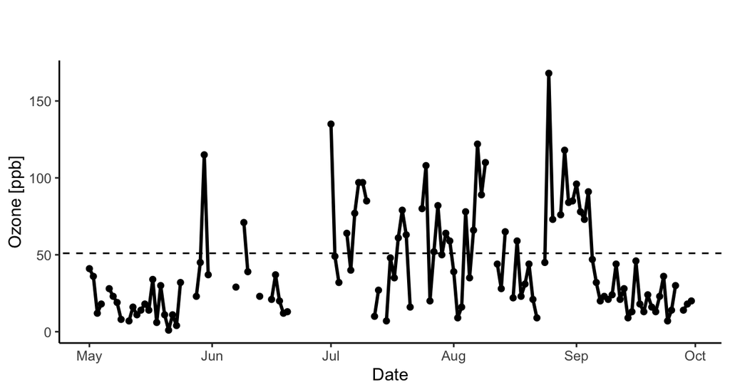

*Figure 1: Time series of daily ozone concentrations in New York in 1973 relative to the WHO threshold of 51 ppb (dashed line).*

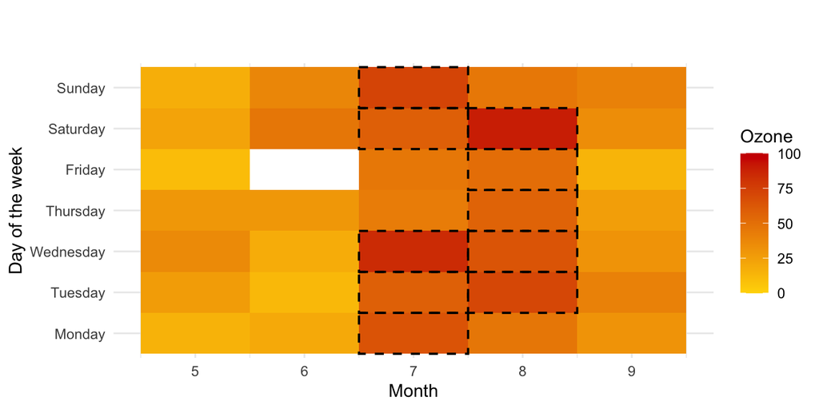

*Figure 2: Ozone aggregated across months and weekdays with days exceeding 51 ppb indicated by dashed borders.*

#### 3.2 Prediction of Ozone

From the three single predictors, temperatures linear model performed best at predicting ozone with an $R^2$ of 0.488 which indicates that roughly 50% of the variation of ozone can be modeled with just temperature (Table 2). The linear models of wind speed and solar radiation performed worse and were only poorly able to predict ozone concentrations.

Table 2: Fit of the different linear model specifications.

| Linear model formula | R2 |
| --- | --- |
| Ozone ~ Temp | 0.488 |
| Ozone ~ Wind | 0.362 |
| Ozone ~ Solar.R | 0.121 |

Comparing the linear models visually, the temperature-ozone association indicates a non-linear relationship and shows increasing ozone concentrations with increasing temperature (Figure 3). There is a steep incline in ozone concentration at high temperatures where the model underestimates ozone concentrations. Wind speed as a predictor had an inverse association with ozone, as the highest concentrations occurred in low wind speed conditions. Wind speeds model also had wider confidence intervals than the temperature model, which again indicates poorer predictive ability. There is no clear visual pattern between ozone and solar radiation, supporting the very poor predictability of ozone shown in Table 2.

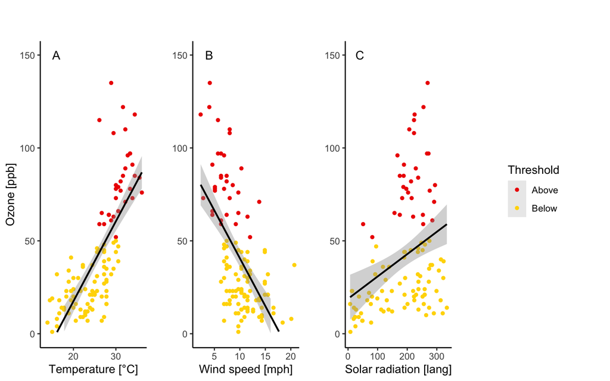

### 4. Discussion

I hypothesized that ozone concentrations would be higher in the summer due to increased solar radiation, and I found a clear seasonal pattern with the highest concentrations in the summer months. However, I did not find the expected increased ozone concentration on weekdays, possibly due to other processes being involved in ozone production and decay than traffic and industry activity. Against expectations, solar radiation predicted ozone worse than wind speed and temperature, possibly because chemical concentrations rely more on temperature and wind speed, which accounts for a dilution of polluted air. Temperature performed best at linearly predicting ozone concentrations but was not sufficiently accurate to serve as a sole predictor in health monitoring programs. In conclusion, New York’s population in 1973 was heavily exposed to dangerous ozone concentrations in the summer months, which often coincided with high temperatures.

### References

[1] Hubbell BJ, Hallberg A, McCubbin DR, Post E. Health-related benefits of attaining the 8-hr ozone standard. Environ Health Perspect. 2005 Jan;113(1):73-82. doi: 10.1289/ehp.7186. PMID: 15626651; PMCID: PMC1253713.

[2] Shan, Danying & Du, Zhenyu & Zhang, Ting & Zhang, Xiulan & Cao, Guan & Liu, Zirui & Yao, Zhixiao & Tang, Ka & Liang, Siyuan. (2023). Variations, sources, and effects on ozone formation of VOCs during ozone episodes in 13 cities in China. Frontiers in Environmental Science. 10. 1084592. 10.3389/fenvs.2022.1084592.

[3] Hu, C., Kang, P., Jaffe, D. A., Li, C., Zhang, X., Wu, K., & Zhou, M. (2021). Understanding the impact of meteorology on ozone in 334 cities of China. In Atmospheric Environment (Vol. 248, p. 118221). Elsevier BV. doi.org/10.1016/j.atmosenv.2021.118221

[4] WHO global air quality guidelines. Particulate matter (PM2.5 and PM10), ozone, nitrogen dioxide, sulfur dioxide and carbon monoxide. Geneva: World Health Organization; 2021. Licence: CC BY-NC-SA3.0 IGO.